# Preprocessing Standard

2025-03-25

## 1 Install packages

```r
install.packages(c("here", "tidyverse", "harmony", "Matrix", "remotes"))
remotes::install_github("satijalab/seurat", "seurat5", quiet = TRUE)
```

## 2 Import packages

```r
library(here)
library(stringr)
library(dplyr)
library(ggplot2)
library(Seurat)
library(readr)
library(purrr)
library(harmony)
library(Matrix)
```

## 3 Download the data

Run in bash

mkdir data

cd data

wget https://ftp.ncbi.nlm.nih.gov/geo/series/GSE116nnn/GSE116256/suppl/GSE116256_RAW.tar -O GSE116256_RAW.tar

tar -xvf GSE116256_RAW.tar

rm GSE116256_RAW.tar

## 4 Set the path to the data folder

```r
data_path = here("./data/")
```

## 5 Get count matrices

```r
# Function to read counts
read_counts <- function(file_path) {
    counts <- read_tsv(file_path)
    counts <- as.data.frame(counts)

    # Moves gene names to row names
    genes <- counts$Gene
    counts <- counts[,-1]
    rownames(counts) <- genes

    return(as.matrix(counts))
}

# Read all count matrices
count_files <- list.files(data_path, pattern = "*.dem.txt.gz", full.names = TRUE)[1:41]
samples <- map_chr(count_files, basename)
samples <- str_replace(samples, "(GSM[0-9]+_.+).dem.txt.gz", "\\1")
names(count_files) <- samples
counts <- map(count_files, read_counts)
```

## 6 Get metadata

```r
# Function to read metadata
read_meta <- function(file_path) {
    meta <- read_tsv(file_path)
    meta <- as.data.frame(meta)

    # Moves gene names to row names
    cells <- meta$Cell
    meta <- meta[,-1]
    rownames(meta) <- cells

    return(meta)
}

# Read all metadata
meta_files <- list.files(data_path, pattern = "*.anno.txt.gz", full.names = TRUE)[1:41]
meta_names <- map_chr(meta_files, basename)
meta_names <- str_replace(meta_names, "(GSM[0-9]+_.+).anno.txt.gz", "\\1")
names(meta_files) <- meta_names
meta <- map(meta_files, read_meta)
```

## 7 Create Seurat object

```r
objs <- map2(counts, meta,
             ~CreateSeuratObject(counts = as(.x, "sparseMatrix"),
                                 meta.data = .y))
merged_seurat <- reduce(objs, function(x, y) {merge(x, y)})
```

## 8 Free up memory

```r
rm(counts, meta, objs)
```

## 9 Add custom metadata

```r
merged_seurat$Temp <- rownames(merged_seurat@meta.data)
merged_seurat@meta.data <- tidyr::separate(merged_seurat@meta.data,
                                    col = Temp,
                                    into = c("Temp2", "Barcode"),
                                    sep = "_")
merged_seurat@meta.data <- tidyr::separate(merged_seurat@meta.data,
                                           col = Temp2,
                                           into = c("Patient_id", "Days_from_diagnosis"),
                                           sep = "-")
merged_seurat@meta.data$Days_from_diagnosis[merged_seurat@meta.data$Days_from_diagnosis %in% c("34p", "34p38n")] <- NA
merged_seurat@meta.data$Days_from_diagnosis <- gsub("^D", "", merged_seurat@meta.data$Days_from_diagnosis)
merged_seurat@meta.data$Days_from_diagnosis <- as.integer(merged_seurat@meta.data$Days_from_diagnosis)

# List of sample groups
sample_groups <- list(
    control = c("BM1", "BM2", "BM3", "BM4", "BM5-34p", "BM5-34p38n"),
    pre_chemo = c("AML1012-D0", "AML210A-D0", "AML419A-D0", "AML916-D0", "AML921A-D0",
                  "AML314-D0", "AML371-D0", "AML475-D0", "AML722B-D0", "AML870-D0", "AML997-D0",
                  "AML329-D0", "AML420B-D0", "AML556-D0", "AML328-D0", "AML707B-D0"),
    post_chemo = c("AML314-D31", "AML371-D34", "AML475-D29", "AML722B-D49", "AML870-D14",
                   "AML997-D35", "AML329-D20", "AML329-D37", "AML420B-D14", "AML420B-D35",
                   "AML556-D15", "AML556-D31", "AML328-D29", "AML328-D113", "AML328-D171",
                   "AML707B-D18", "AML707B-D41", "AML707B-D97", "AML707B-D113")
)

# Function to get group
get_group <- function(sample) {
    for (group in names(sample_groups)) {
        if (sample %in% sample_groups[[group]]) return(group)
    }
}

# Add condition column
merged_seurat$Condition <- map_chr(merged_seurat$orig.ident, get_group)

# List of additional information about patients
sample_info <- list(
  BM1 = c(Gender = "M", Age = 52),
  BM2 = c(Gender = "M", Age = 21),
  BM3 = c(Gender = "M", Age = 56),
  BM4 = c(Gender = "M", Age = 23),
  BM5 = c(Gender = "M", Age = 45),
  AML1012 = c(Gender = "F", Age = 32),
  AML210A = c(Gender = "M", Age = 67),
  AML419A = c(Gender = "F", Age = 54),
  AML916 = c(Gender = "F", Age = 57),
  AML921A = c(Gender = "M", Age = 42),
  AML314 = c(Gender = "M", Age = 54),
  AML371 = c(Gender = "M", Age = 51),
  AML475 = c(Gender = "M", Age = 70),
  AML722B = c(Gender = "F", Age = 52),
  AML870 = c(Gender = "M", Age = 32),
  AML997 = c(Gender = "M", Age = 62),
  AML329 = c(Gender = "F", Age = 73),
  AML420B = c(Gender = "M", Age = 58),
  AML556 = c(Gender = "M", Age = 70),
  AML328 = c(Gender = "F", Age = 74),
  AML707B = c(Gender = "M", Age = 26)
)

# Init columns Gender and Age
merged_seurat@meta.data$Gender <- NA
merged_seurat@meta.data$Age <- NA

# For loop to fill columns Gender and Age
for (sample_name in unique(merged_seurat@meta.data$Patient_id)) {
    gender <- sample_info[[sample_name]]["Gender"]
    age <- sample_info[[sample_name]]["Age"]

    # Fill columns Gender and Age
    merged_seurat@meta.data[merged_seurat@meta.data$Patient_id == sample_name, "Gender"] <- gender
    merged_seurat@meta.data[merged_seurat@meta.data$Patient_id == sample_name, "Age"] <- age
}
```

So, we have a Seurat object with 41 samples. In metadata, we have a columns `Condition`, `Patient_id`, `Days_from_diagnosis` and `CellType`.

`Condition` is a factor with three levels: `control`, `pre_chemo` and `post_chemo`. In `control` group we have 6 samples that starts with `BM`. In `pre_chemo` group we have 16 samples that ends with `-D0`. In `post_chemo` group we have 19 samples that ends with `-DXX` where `XX` is the number of days after chemotherapy.

`Patient_id` is a factor that represents the patient id (like `AML1012` or `BM1`).

`Days_from_diagnosis` is a factor that represents the days from diagnosis (like `0` or `113`) or `NA` for control.

`CellType` is a factor with 22 levels: `GMP`, `GMP-like`, `Prog-like`, `ProMono-like`, `HSC-like`, `cDC-like`, `Mono-like`, `Mono`, `Prog`, `cDC`, `HSC`, `ProMono`, `earlyEry`, `CTL`, `T`, `Plasma`, `ProB`, `NK`, `B`, `lateEry`, `pDC` or `NA`. These types predicted by the authors of the study.

Also we have two additional columns `Gender` and `Age` that we filled with information about patients.

## 10 Check cell counts by groups

```r
table(merged_seurat$Condition)
```

```
##
##    control post_chemo  pre_chemo
##       7698      15027      15685
```

## 11 Filter cells by mitochondrial genes

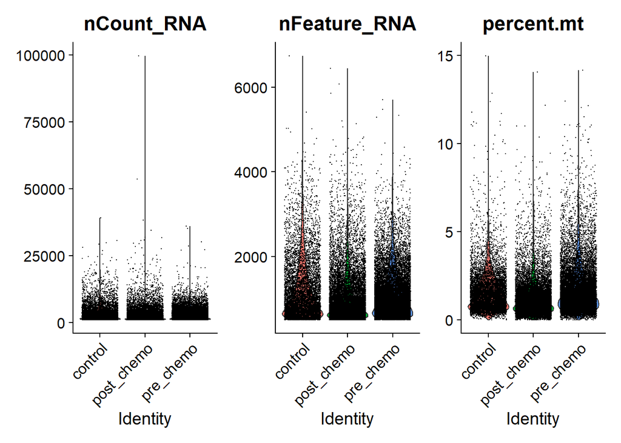

```r
merged_seurat$percent.mt <- PercentageFeatureSet(merged_seurat, pattern="^MT-")
VlnPlot(merged_seurat, features = c("nCount_RNA","nFeature_RNA","percent.mt"), group.by = "Condition")
```

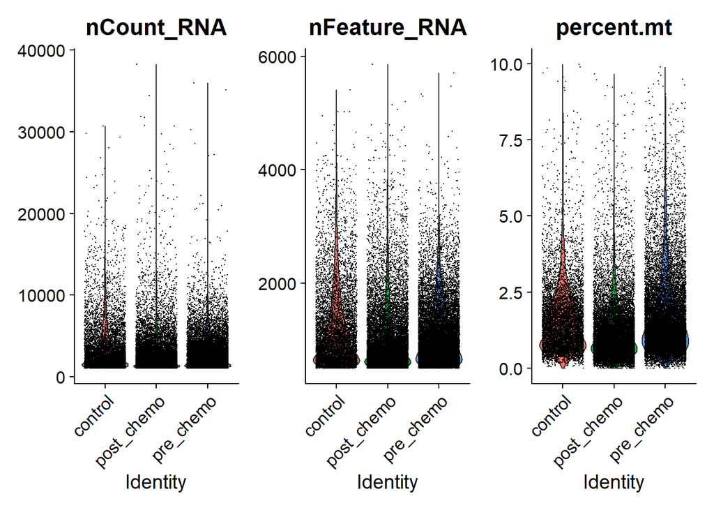

```r
m_seurat <- subset(merged_seurat, subset = nCount_RNA < 50000 & nFeature_RNA > 200 & nFeature_RNA < 6000 & percent.mt < 10)
VlnPlot(m_seurat, features = c("nCount_RNA","nFeature_RNA","percent.mt"), group.by = "Condition")
```

## 12 Visualize feature-feature relationships

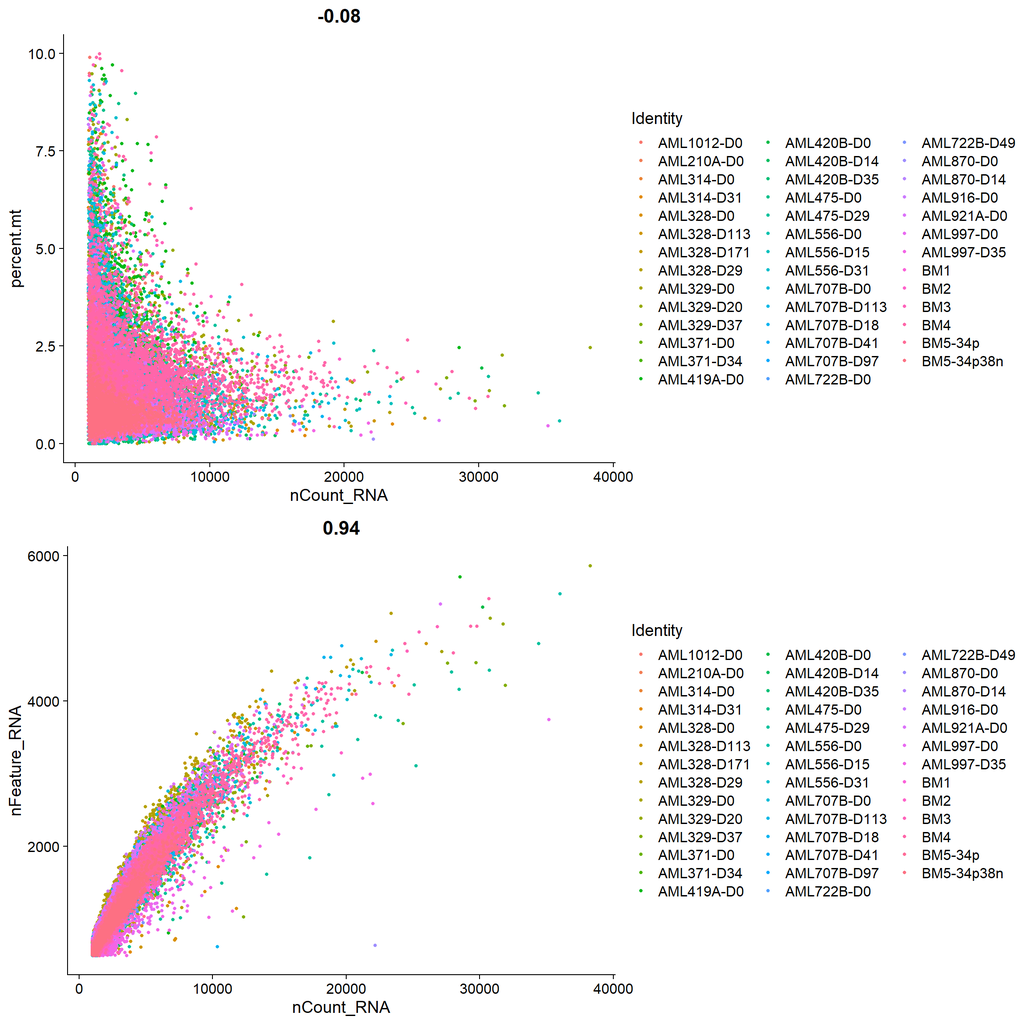

```r
plot1 <- FeatureScatter(m_seurat, feature1 = "nCount_RNA", feature2 = "percent.mt")
plot2 <- FeatureScatter(m_seurat, feature1 = "nCount_RNA", feature2 = "nFeature_RNA")
gridExtra::grid.arrange(plot1, plot2, nrow = 2)
```

## 13 Free up memory

```r
rm(merged_seurat)
```

## 14 Normalize data

```r
m_seurat <- m_seurat %>%
    NormalizeData(normalization.method = "LogNormalize", scale.factor = 10000) %>%
    FindVariableFeatures(selection.method = "vst", nfeatures = 2000) %>%
    ScaleData()
```

## 15 Run PCA

```r
m_seurat <- RunPCA(m_seurat, npcs = 50)
```

## 16 Create Elbow plot to determine number of PCs

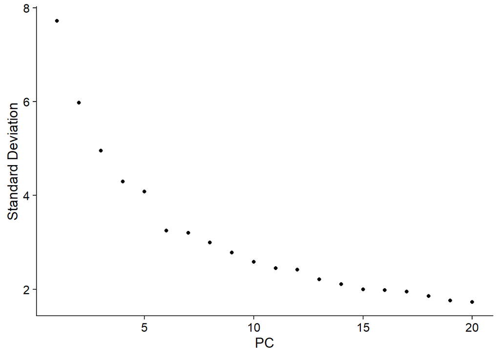

```r
ElbowPlot(m_seurat)
```

Let’s say that the elbow plot shows that the optimal number of PCs is 20.

## 17 Run UMAP before Harmony

```r
m_seurat <- RunUMAP(m_seurat, dims = 1:20)
```

## 18 Plot UMAP for different groupings

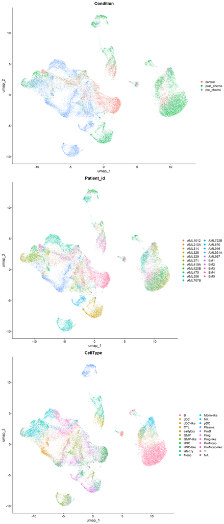

```r
p1 <- DimPlot(m_seurat, reduction = "umap", group.by = "Condition")
p2 <- DimPlot(m_seurat, reduction = "umap", group.by = "Patient_id")
p3 <- DimPlot(m_seurat, reduction = "umap", group.by = "CellType")
gridExtra::grid.arrange(p1, p2, p3, nrow = 3)
```

Looks good, but we need to correct for batch effects with Harmony.

## 19 Run Harmony

```r
harmonized_seurat <- RunHarmony(m_seurat,
                                group.by.vars = c("Condition"),
                                reduction = "pca",
                                reduction.save = "harmony")
```

## 20 Free up memory

```r
rm(m_seurat)
```

## 21 Run UMAP and clusterization after Harmony

```r
harmonized_seurat <- harmonized_seurat %>%
    RunUMAP(reduction = "harmony", dims = 1:20) %>%
    FindNeighbors(reduction = "harmony", dims = 1:20) %>%
    FindClusters(resolution = 0.6)
```

## 22 Plot UMAP for different groupings after Harmony

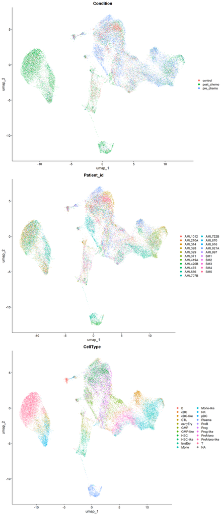

```r
p4 <- DimPlot(harmonized_seurat, reduction = "umap", group.by = "Condition")
p5 <- DimPlot(harmonized_seurat, reduction = "umap", group.by = "Patient_id")
p6 <- DimPlot(harmonized_seurat, reduction = "umap", group.by = "CellType")
gridExtra::grid.arrange(p4, p5, p6, nrow = 3)
```

## 23 Before and after pairwise comparison

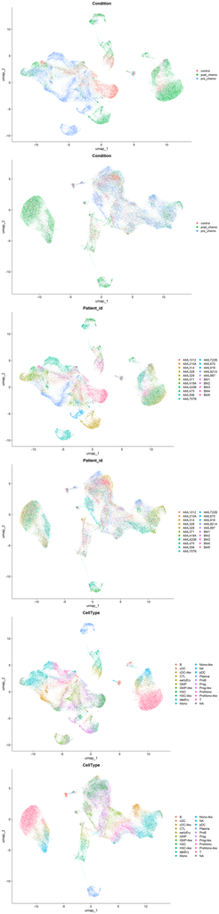

```r
gridExtra::grid.arrange(p1, p4, p2, p5, p3, p6, nrow = 6)
```

## 24 Plot UMAP with our clusters and original clusters

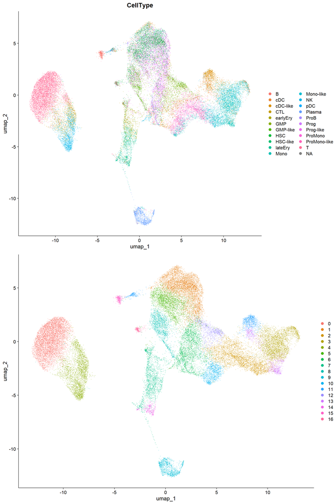

```r
p7 <- DimPlot(harmonized_seurat, reduction = "umap")
gridExtra::grid.arrange(p6, p7, nrow = 2)
```

## 25 Save Seurat object

```r
saveRDS(harmonized_seurat, "prepared_seurat_obj_standard.RDS")
```